# Code Along: Data Visualization with `ggplot2`

### Hosted by the Graduate Students of Open Coding Hour

This 1 hour webinar will focus on making three kinds of visualizations: time-series line graphs, bar charts, and distribution plots. For examples of other kinds of plots (in addition to data transformation vignettes), check the class website for the 4 day R course taught by myself and Cory DuPai: https://rachaelcox.github.io/classes/IntroR_summer_2020.html

**September 30, 2020**

## 1. Plotting x-y relationships (e.g. time series, correlations)

We will use the `brewmats` dataset, which is sourced from the US Alcohol and Tobacco Tax and Trade Bureau (TBB, https://www.ttb.gov/beer/statistics), scraped by the TidyTuesday group and cleaned by me. The `brewmats` dataset contains the following variables:

- `data_type` = denotes that all amounts of material used are given in pounds (lbs)
- `material_type` = materials belong in one of two categories, grain (e.g., wheat) or non-grain (e.g., sugar)
- `type` = specific material details (e.g., malt, corn, rice, barley, wheat, hops, sugar, etc
- `year` = year the amount of materials used was recorded (2008-2015)
- `month` = month the amount of materials used was recorded (1=January, 2=February, 3=March, etc)
- `month_usage_by_type` = total amount of material usage by type per month (lbs)
- `month_sum_all_types` = total amount of material used for *all* types (lbs)
- `year_sum_by_type` = total amount of material used by type per year

[figure not shown]

```r
# download the `brewmats` dataset
brewmats <- read_csv("https://rachaelcox.github.io/classes/datasets/brewmats.csv")
```

**Code Along:** Plot the total monthly usage of all brewing materials (`month_sum_all_types`) on the y-axis for every `month` in the dataset on the x-axis, as a line graph colored by `year` using `geom_line()`.

```r
# R code here
```

**Practice:** Plot the yearly usage (`year_sum_by_type`) of each type of brewing materials on the y-axis, for every `year` in the dataset on the x-axis, as a line graph colored by `type` using `geom_line()`. Remember to map `group = type` so that ggplot knows how which lines you want to connect.

```r
# R code here
```

## 2. Plotting amounts (e.g. bar graphs, heat maps)

For this section, we will use the `mushrooms` dataset (obtained from Kaggle and cleaned by me), which contains the following information:

- `class` = whether the mushroom is edible or poisonous
- `cap_shape` = shape of the mushroom cap, e.g., bell, conical, convex, flat, etc
- `cap_color` = color of the mushroom cap, e.g., brown, buff, cinnamon, gray, etc
- `odor` = smell of the mushroom (almond, anise, creosote, fishy foul, musty, pungent, none)
- `gill_spacing` = spacing between mushroom gills, aka the underside of the mushroom cap (close, crowded or distant)
- `gill_size` = size of mushroom gills (broad or narrow)
- `gill_color` = color of mushroom gills (black, brown, etc)
- `stalk_shape` = shape of the mushroom stalk (enlarging or tapering)
- `stalk_root` = type of stalk root (bulbous, club, cup, rooted, etc)
- `veil_type` = type of veil on the mushroom (partial or universal)
- `veil_color` = color of the veil (brown, orange, white or yellow)
- `ring_number` = number of rings on the stalk of the mushroom (0, 1 or 2)
- `ring_type` = description of the ring(s), if any, found on the stalk, e.g., flaring, large, pendant, etc
- `spore_print_color` = color of spores collected on a sheet of paper as a print (black, brown, yellow, etc)
- `population` = description of nearby mushrooms of the same species, if any; can be abundant, clustered, numerous, scattered, several, and solitary
- `habitat` = where the mushroom was found (grasses, leaves, meadows, paths, urban, waste, woods)

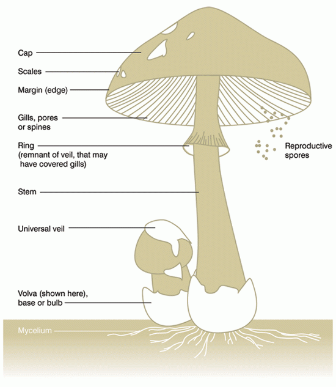

```r
# download the `mushrooms` dataset
mushrooms <- read_csv("https://rachaelcox.github.io/classes/datasets/mushrooms.csv")
```

**Code Along:** Plot a bar graph for counts of mushrooms found in each `habitat`, colored by `class` (edible or poisonous) using `geom_bar()`.

```r
# R code here
```

**Practice:** Plot a bar graph for counts of mushrooms of each type of `odor`, colored by `class` (edible or poisonous) using `geom_bar()`.

```r
# R code here
```

## 3. Plotting distributions (e.g., box plots, histograms, density plots)

For this section, we will use the `wine` dataset (obtained from Kaggle and cleaned by me), which contains the following variables:

- `type`: whether the wine is red or white
- `quality`: median score between 0 and 10 as blindly graded by wine experts
- `quality_grade`: quality category given to each rating based on distribution of ratings (low, med, high)
- `alcohol`: the percent alcohol content of the wine (% by volume)
- `alcohol_grade`: relative amount of alcohol compared to all wines (low, med, high)
- `pH`: describes how acidic or basic a wine is on a scale from 0 (very acidic) to 14 (very basic); most wines are between 3-4 on the pH scale
- `acidity_grade`: acidity intensity (low, med, higj)
- `fixed_acidity`: most acids involved with wine or fixed or nonvolatile/do not evaporate readily (tartaric acid - g / dm^3)
- `volatile_acidity`: the amount of acetic acid in wine, which at too high of levels can lead to an unpleasant, vinegar taste (acetic acid - g / dm^3)
- `citric_acid`: found in small quantities, citric acid can add freshness and flavor to wines (g / dm^3)
- `residual_sugar`: the amount of sugar remaining after fermentation stops; it's rare to find wines with less than 1 gram/liter and wines with greater than 45 grams/liter are considered sweet (g / dm^3)
- `chlorides`: the amount of salt in the wine (sodium chloride - g / dm^3)
- `free_sulfur_dioxide`: the free form of SO2 exists in equilibrium between molecular SO2 (as a dissolved gas) and bisulfite ion; it prevents microbial growth and the oxidation of wine (mg / dm^3)
- `total_sulfur_dioxide`: amount of free and bound forms of S02; in low concentrations, SO2 is mostly undetectable in wine, but at free SO2 concentrations over 50 ppm, SO2 becomes evident in the nose and taste of wine (mg / dm^3)
- `density`: degree of consistency measured by mass per unit volume (g / cm^3)
- `sulphates`: a wine additive which can contribute to sulfur dioxide gas (S02) levels, wich acts as an antimicrobial and antioxidant (potassium sulphate - g / dm^3)

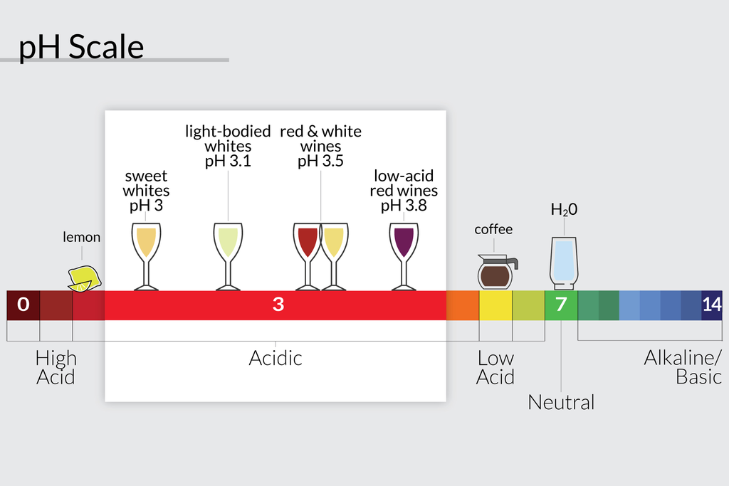

Typical pH of Wine Types

```r
# download the `wine` dataset
wine <- read_csv("https://rachaelcox.github.io/classes/datasets/wine_features.csv")
```

**Code Along:** Plot the distribution of pH for each wine type (i.e., red or wine) by mapping `pH` to the x-axis, coloring by `type`, and calling `geom_density()`. Then, use `geom_boxplot()` to visualize the distribution of `pH` across `quality_grade`, again coloring by `type`.

```r
# R code here
```

**Practice:** Choose a numeric variable you are interested in. Plot its distribution relative to a categorical variable, e.g., `type`, `quality_grade`, `alcohol_grade` or `acidity_grade`. Use `geom_density()`, `geom_boxplot()`, and/or `geom_violin()`.

```r
# R code here
```